# My brief analysis about the Weight Lifting Exercises

Mauricio Paletta

March 03, 2018

## Synopsis

This report describes an own prediction model related to the Weight Lifting Exercises. The original work, including the data, is title “Qualitative Activity Recognition of Weight Lifting Exercises” and is from: Velloso, E.; Bulling, A.; Gellersen, H.; Ugulino, W.; Fuks, H. (Proceedings of 4th International Conference in Cooperation with SIGCHI, Stuttgart, Germany, ACM SIGCHI, 2013).

In order to reproduce the same results presented in this paper, a seed equal to 965 was used.

## The data and cross validation strategy

The Weight Lifting Exercises consists of the following: Six young health participants were asked to perform one set of 10 repetitions of the Unilateral Dumbbell Biceps Curl in five different fashions (the predictor):

- Class A: Exactly according to the specification,
- Class B: Throwing the elbows to the front,
- Class C: Lifting the dumbbell only halfway,
- Class D: Lowering the dumbbell only halfway, and
- Class E: Throwing the hips to the front.

The raw data has 19622 observations and 160 variables. However several variables as for example those with the prefix “var_”, “avg_”, “stddev_” and others are unuseful for the machine learning model (these data have NA values). There are also several rows that can be removed from the raw data because are statistical results of capture windows (they are identified because they have the value “yes” in the variable “new_window”).

On the other hand, the raw data is ordered according to the class (first the data classified as A, then the Bs and so on). For the training process is advisable to randomly regroup the data.

After pre-processing the raw data, the resulting dataset has 19216 observations and 53 variables. This dataset was randomly splitted in a training set of 75% of the data and a remaining 25% testing set.

## The Model

After reviewing the remaining variables of the dataset and the original paper of this work, it is possible to notice 4 different groups of variables grouped according to the device for capturing the data: belt, arm, dumbbell and forearm.

In order to reduce the complexity of the problem (because there are many variables involved) and therefore reduce the calculation time for the training process, the strategy of this machine learning model is to make a model for each of these 4 groups in order to learn the influence of the capture device on the predictor and then a final model that learns from the combination of the 4 devices.

To decide which method to use in these models, let’s first take a look at the variances of each of the variables and their influence on each of the 5 classes of the predictor:

```
##                           varA      varB      varC      varD      varE
## roll_belt              3626.05   3606.71   3724.71   3774.86   4983.42
## pitch_belt              555.62    557.39    505.69    447.12    378.82
## yaw_belt              10029.69   9276.70   9540.49   7918.03   7684.02
## total_accel_belt         53.49     56.12     55.10     51.45     83.80
## gyros_belt_x              0.03      0.04      0.03      0.04      0.08
## gyros_belt_y              0.00      0.00      0.00      0.01      0.01
## gyros_belt_z              0.02      0.02      0.02      0.12      0.13
## accel_belt_x            873.76    886.44    841.99    760.29    984.50
## accel_belt_y            777.71    799.55    798.78    912.33    827.23
## accel_belt_z           9653.22   9102.86   9521.23   9519.70  12482.29
## magnet_belt_x          3870.21   3979.48   3637.45   3255.03   5598.67
## magnet_belt_y           436.37    358.25    423.18   2360.29   2500.69
## magnet_belt_z          1965.63   2081.75   1935.48   5061.24  10457.66
## roll_arm               7054.97   5251.42   3236.25   3108.29   5517.60
## pitch_arm              1196.30   1041.65    770.22    718.00    613.02
## yaw_arm                7584.70   4702.76   4548.42   2879.19   3865.01
## total_accel_arm          84.16    122.77    105.87    109.54    131.51
## gyros_arm_x               1.76      5.45      3.81      3.77      6.17
## gyros_arm_y               0.33      1.19      0.71      0.45      1.11
## gyros_arm_z               0.24      0.34      0.33      0.30      0.36
## accel_arm_x           33383.74  30336.46  29033.81  33728.47  24030.82
## accel_arm_y           10277.21  14062.27  11725.32  10535.74  13351.78
## accel_arm_z           10310.80  24066.71  15899.80  16350.00  26824.14
## magnet_arm_x         196050.10 178526.81 178579.87 144849.88 156347.40
## magnet_arm_y          29349.44  50778.02  37377.13  26481.89  45083.33
## magnet_arm_z          57141.55 153163.18  86814.50  81341.38 137148.96
## roll_dumbbell          3507.14   5287.55   5807.96   2829.89   5454.04
## pitch_dumbbell         1181.24   1672.14    765.30   1242.77   1390.32
## yaw_dumbbell           8197.96   5481.73   6145.93   7259.35   5910.36
## total_accel_dumbbell    150.14     79.65     90.16     90.12     82.76
## gyros_dumbbell_x         10.23      0.27      0.07      0.18      0.20
## gyros_dumbbell_y          0.71      0.46      0.08      0.10      0.52
## gyros_dumbbell_z         24.57      0.18      0.09      0.05      0.15
## accel_dumbbell_x       5222.20   5003.47   2917.75   2875.90   4155.07
## accel_dumbbell_y       4550.20   8441.88   6577.98   4224.76   8716.53
## accel_dumbbell_z      16757.45   9202.47   9687.54   9353.89  10890.05
## magnet_dumbbell_x    108709.12 108570.03 127955.10 124744.41 101174.59
## magnet_dumbbell_y     75319.16 138390.58  88422.90 110991.02 133962.74
## magnet_dumbbell_z     20971.78  25826.21  10378.97  18051.36  17777.86
## roll_forearm           6034.51  12875.65  11320.72  16432.16  14294.63
## pitch_forearm          1313.29    453.88    296.49    418.09    369.38
## yaw_forearm           11532.47  10151.87   8361.96  11744.77  10458.96
## total_accel_forearm     116.44    103.42     81.62     71.25    100.84
## gyros_forearm_x           0.47      0.53      0.35      0.24      0.49
## gyros_forearm_y          26.02      6.59      4.05      4.46      6.94
## gyros_forearm_z          13.22      0.54      0.28      0.26      0.49
## accel_forearm_x       33458.44  29810.82  27255.91  21922.04  34961.06
## accel_forearm_y       24457.67  54745.10  28377.39  40346.86  54863.81
## accel_forearm_z       19599.06  18802.46  18358.17  19481.65  19430.96
## magnet_forearm_x     132732.80  81082.27 104605.34 101858.16 132810.64
## magnet_forearm_y     180913.19 333892.77 174939.47 240411.88 330720.92
## magnet_forearm_z     124779.94 157700.19 119860.95 125054.64 145784.82
```

As can be seen in the table of variances, most of the variables have very high values, indicating that there is a lot of noise in the capture of the data. Then, following the same decision of the authors of this work, it is better to apply the random forest method for each of the models associated to the capture devices.

Aiming to reduce the complexity of the problem, instead of taking the three variables referred to a coordinate (x, y, z) the average of the three values is assumed. It is thus reduced to 1 variable for each group of three coordinates.

Plot 1 shows the first 100 results of the predictions of the models of the 4 devices. The upper line shows the hits between the predicted and the real class; the bottom line shows the inequalities. As we can seen, although there are a lot of successes in each case, there are still many inequalities (the accuracy is 0.91).

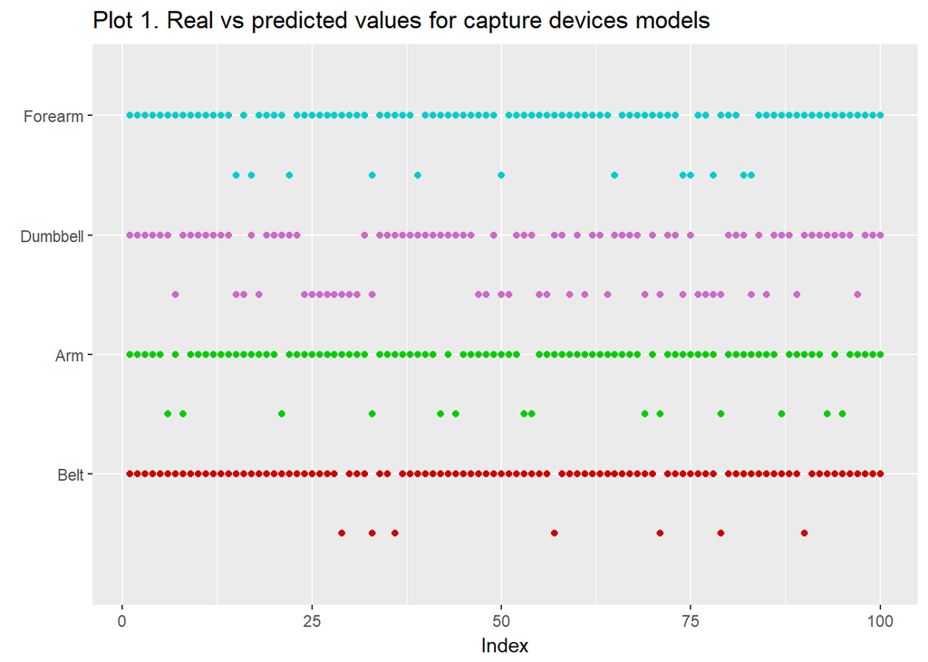

The next and final step is combine the 4 predictors in a final general model. For this case I chose the method Naive Bayes because it assumes independence between features as well as that each of the class densities are products of marginal densities (they assume that the inputs are conditionally independent in each class). The confusion matrix and accuracy is as follows:

```
## Confusion Matrix and Statistics
##
##           Reference
## Prediction    A    B    C    D    E
##          A 1343   10    6    1    1
##          B   19  899   19    0    2
##          C    1   16  801   22    3
##          D    2    1   10  761    1
##          E    2    3    2    2  875
##
## Overall Statistics
##
##                Accuracy : 0.9744
##                  95% CI : (0.9695, 0.9787)
##     No Information Rate : 0.2847
##     P-Value [Acc > NIR] : <2e-16
##
##                   Kappa : 0.9676
##  Mcnemar's Test P-Value : 0.1959
##
## Statistics by Class:
##
##                      Class: A Class: B Class: C Class: D Class: E
## Sensitivity            0.9824   0.9677   0.9558   0.9682   0.9921
## Specificity            0.9948   0.9897   0.9894   0.9965   0.9977
## Pos Pred Value         0.9868   0.9574   0.9502   0.9819   0.9898
## Neg Pred Value         0.9930   0.9922   0.9907   0.9938   0.9982
## Prevalence             0.2847   0.1935   0.1745   0.1637   0.1837
## Detection Rate         0.2797   0.1872   0.1668   0.1585   0.1822
## Detection Prevalence   0.2834   0.1955   0.1756   0.1614   0.1841
## Balanced Accuracy      0.9886   0.9787   0.9726   0.9824   0.9949
```

Plot 2 shows the comparison between the real and prediction values resulting from the general model. As we can seen the accuracy is 0.97.

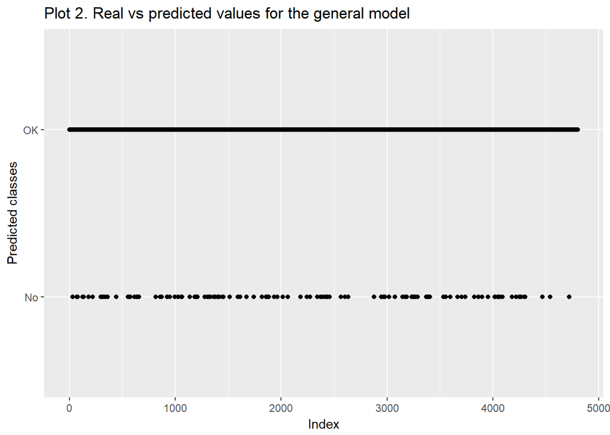

## Using the original test file

Below the results (classification) by using the model presented in this paper with the test file given by the authors of this work.

```
##  [1] B A B A A E D B A A B C B A E E A B B B
## Levels: A B C D E
```

## Summary

It was important to carry out a preliminary analysis of the data. The application of filters allowed to reduce the complexity of the learning process. An analysis of the variances of the variables allowed to decide the method to be used in the model. The use of the strategy of combination of models allowed to obtain good results in the prediction.